# NBA数据降维分析

DWB

2020/12/26

## $\textbf{·}$ 数据读入

将训练数据集NBA.xlsx读入，并进行标准化处理：

```r
setwd("E:\\大学\\课程\\专业必修\\大三上\\统计机器学习\\HW\\HW9\\NBA数据分析降维")
library(openxlsx)
data <- read.xlsx("NBA.xlsx")
data[, -1] = scale(data[, -1])
```

## $\textbf{·}$ 主成分分析

### $\textbf{·}$ 主成分选择

对所有的自变量（因此，不包含因变量“生涯总得分”）进行主成分分析，绘制碎石图，并选择主成分个数：

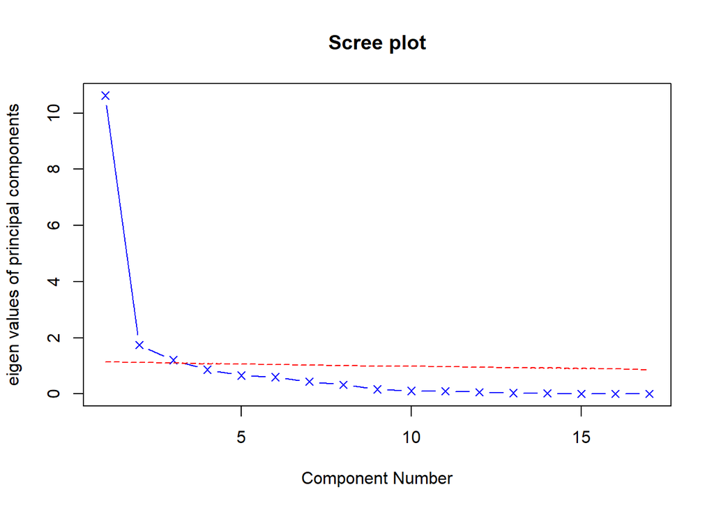

```
## Parallel analysis suggests that the number of factors =  NA  and the number of components =  3
```

```r
library(psych)
fa.parallel(data[, 2:18], fa = "pc", show.legend = F, main = "Scree plot")
```

从图中可以看到，虽然拐点出现在2，但是是无论按照累计方差贡献率，还是按照Kaiser准则，都不能只保留一个主成分。这里我们选择三个主成分。

### $\textbf{·}$ 结果解读

```r
pr <- princomp(data[, 2:18])
summary(pr)
```

```
## Importance of components:
##                           Comp.1    Comp.2     Comp.3     Comp.4     Comp.5
## Standard deviation     3.2595512 1.3222444 1.09924743 0.92902888 0.81337097
## Proportion of Variance 0.6252362 0.1028850 0.07110816 0.05079102 0.03893192
## Cumulative Proportion  0.6252362 0.7281212 0.79922937 0.85002039 0.88895231
##                            Comp.6     Comp.7     Comp.8      Comp.9     Comp.10
## Standard deviation     0.77461728 0.66182260 0.57464925 0.410470886 0.333859992
## Proportion of Variance 0.03531042 0.02577577 0.01943275 0.009915012 0.006559297
## Cumulative Proportion  0.92426273 0.95003850 0.96947125 0.979386264 0.985945561
##                            Comp.11     Comp.12     Comp.13     Comp.14
## Standard deviation     0.309781071 0.259974821 0.192228529 0.151878638
## Proportion of Variance 0.005647266 0.003977325 0.002174524 0.001357444
## Cumulative Proportion  0.991592827 0.995570152 0.997744676 0.999102120
##                            Comp.15      Comp.16      Comp.17
## Standard deviation     0.085458113 0.0733077224 0.0507997152
## Proportion of Variance 0.000429769 0.0003162481 0.0001518627
## Cumulative Proportion  0.999531889 0.9998481373 1.0000000000
```

从主成分分析的结果可以看出，保留三个主成分符合Kaiser准则，并且累计方差贡献率达到$79.9\%$，较为合理。

查看前三个主成分关于各个原始变量的系数如下：

```r
round(unclass(pr$loadings[, 1:3]), 3)
```

```
##                   Comp.1 Comp.2 Comp.3
## 出场数             0.282  0.040  0.075
## 上场总时间（min）  0.298  0.055  0.005
## 投篮率             0.059 -0.038  0.720
## 命中次数           0.293  0.124 -0.019
## 出手次数           0.294  0.098 -0.033
## 三分投球率         0.066 -0.470  0.334
## 三分命中次数       0.198 -0.510 -0.185
## 三分出手次数       0.205 -0.500 -0.190
## 罚球率             0.087 -0.117  0.502
## 罚球命中次数       0.285  0.138 -0.043
## 罚球出手次数       0.284  0.182 -0.030
## 篮板数             0.257  0.263  0.060
## 助攻次数           0.265 -0.030 -0.101
## 抢断次数           0.266 -0.164 -0.083
## 盖帽次数           0.206  0.195  0.083
## 失误次数           0.269 -0.124 -0.077
## 犯规次数           0.281  0.146  0.066
```

我们可以发现，第一个主成分关于各个变量的系数相对比较综合，因此明星球员（出场数多、球权多）、在NBA效力时间久的球员第一主成分得分会高；第二主成分主要与三分命中率、三分命中次数、三分出手次数有关，衡量一个球员的三分能力，又因为其系数均为负，因此往往是三分出手多、命中多的后卫球员会有较低的第二主成分得分，内线球员如中锋等，第二主成分得分反而会高；第三主成分主要由投篮命中率、罚球命中率有关，一般而言内线球员因为在板下出手多，所以投篮命中率会高，在外线出手的球员一般会较低，但是第三主成分同时也受罚球命中率的影响，所以内线球员得分也不会过高，相比前两个主成分，第三主成分的绝对值应该会普遍偏小。

## $\textbf{·}$ 主成分得分解读

计算每一位球员的主成分得分，并挑选几位球员进行查看与解读：

```r
index <- c(1, 5, 14, 36, 37, 2000)
scores <- pr$scores[, 1:3]
scores <- scale(apply(scores, 2, as.numeric))
scores <- cbind(data[, 1], round(pr$scores[, 1:3], 2))
scores[index, ]
```

```
##                        Comp.1  Comp.2   Comp.3
## 1    "勒布朗-詹姆斯"   "34.36" "-4.51"  "-5.63"
## 5    "沙奎尔-奥尼尔"   "24.24" "10.43"  "0.48"
## 14   "哈基姆-奥拉朱旺" "17.7"  "6.16"   "1.06"
## 36   "斯蒂芬-库里"     "13.43" "-10.57" "-3.92"
## 37   "詹姆斯-哈登"     "14.24" "-6.29"  "-3.15"
## 2000 "卢克-辛歇尔"     "-1.59" "-0.01"  "2.69"
```

我们可以看到，相比前面这些明星球员，“卢克-辛歇尔”的第一主成分就很低，而“勒布朗-詹姆斯”的季后赛出场数位于历史第二，球权等也很多，因此其第一主成分得分很高；在第二主成分上，可以看到以三分著称的“斯蒂芬-库里”第二主成分得分较低，而内线球员“沙奎尔-奥尼尔”、“哈基姆-奥拉朱旺”因为三分出手很少，因此第二主成分得分较高；第三主成分也是，内线球员因为投篮命中率一般较高，因此也会有较高的第三主成分得分；与之前的分析相符。

## $\textbf{·}$ k-means聚类

根据聚类个数和样本点到聚类中心距离的平方和绘制碎石图，确定聚类的类别个数如下：

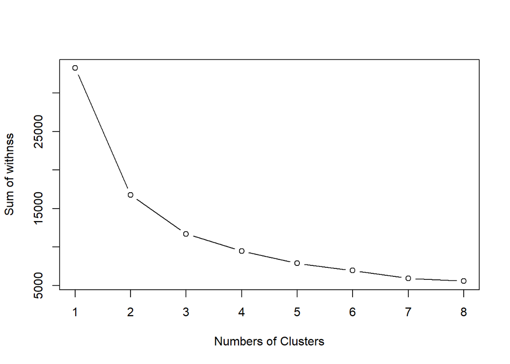

```r
sg <- rep(0,8)
set.seed(1)
sg <- 1:8
sst <- sapply(sg, function(i){sum(kmeans(scores[, 2:4], centers = i)$withinss)})

par(family = 'Hei')
plot(sg, sst, type = 'b', xlab = 'Numbers of Clusters', ylab = "Sum of withnss")
```

```r
for(i in 1:8){
  sg[i] <- sum(kmeans(scores[, 2:4],centers = i)$withinss)
}
```

```r
set.seed(1)
kmean <- kmeans(scores[, 2:4], centers = 3)
```

将可视化结果展示如下：

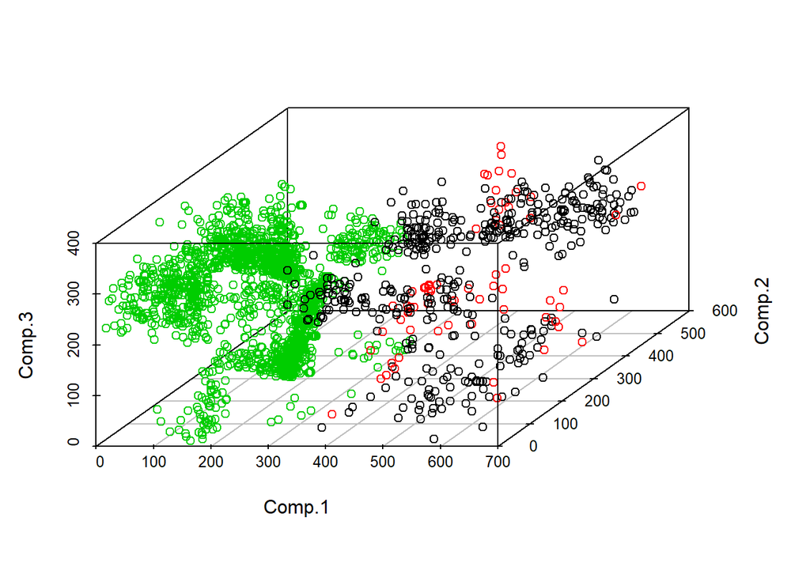

```r
scores <- as.data.frame(scores)
scores$cluster <- kmean$cluster
library(scatterplot3d)
plot3d <- with(scores, scatterplot3d(Comp.1, Comp.2, Comp.3, color = as.numeric(cluster)))
```

可以看到，数据聚成3类，其中绿色最多，因为其第一主成分值较小，推测为非明星球员，这种角色球员在NBA中数量很多，符合常理；根据我们之前的分析，另外两种颜色第一主成分均较大，而二、三主成分有所差异，可能分别代表明星球员中的外线和内线球员，他们具有不同的第二主成分和第三主成分得分。

## $\textbf{·}$ 编程练习（PCA函数）

首先，定义PCA函数如下：

```r
PCA <- function(Dat, max.k){
  R <- cor(Dat)
  Eig <- eigen(R)
  vars <- Eig$values[1:max.k]
  coef <- Eig$vectors[, 1:max.k]
  return(list(vars = vars, alphas = coef))
}
```

使用自定义的PCA函数，对NBA数据集的所有自变量（不包含因变量“生涯总得分”）进行分析，并绘制碎石图如下：

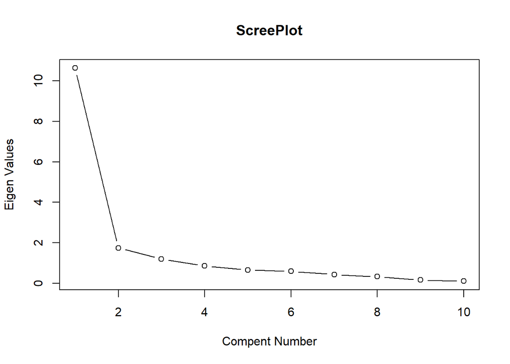

```r
data <- read.xlsx("NBA.xlsx")
test.dat <- data[, 2:18]
pca <- PCA(test.dat, 10)

plot(1:10, pca$vars, type ="b", main = "ScreePlot", xlab = "Compent Number", ylab = "Eigen Values")
```